# Household Survey Analysis

Preliminary Results

Published

May 15, 2025

This document presents an initial analysis of the household survey responses from invited residents living within 0.1 mile (0.16 km) of Lafayette Park in Norfolk and Paradise Creek Nature Park in Portsmouth.

The survey itself was constructed using Qualtrics and participants were recruited using mailed postcards, email, and [SMS text messaging](https://rumbleup.com). The household survey response rate was lower than expected, despite compensation in the form of a $35 gift card as a financial incentive and we received 93 responses from 486 invitations for a response rate of 19.1% percent.

## Who Participated?

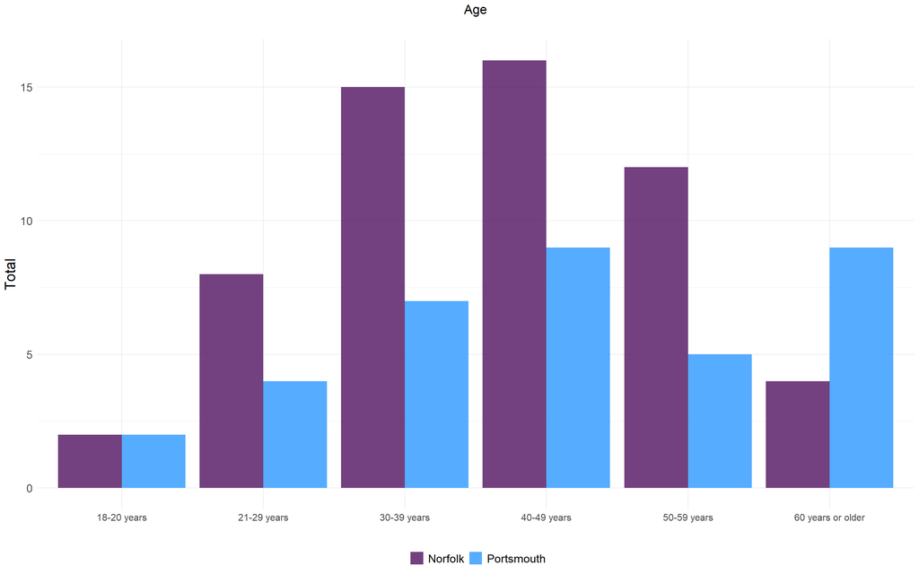

```r
recoded_data %>%
  group_by(City) %>%
  dplyr::select(Age, City) %>%
  count(Age) %>%
  ggplot() +
  geom_bar(aes(y = n, x = Age, fill = City), stat = "identity", position = "dodge", alpha = 0.75) +
    scale_fill_manual(name = "",  values = c("#440154FF", "dodgerblue"), labels = c("Norfolk", "Portsmouth")) +
  labs(x = "", y = "Total", title =  "Age", subtitle = "") +
  theme_minimal() +
  theme(legend.position="bottom",
        plot.subtitle = element_text(hjust = 0.5),
        plot.title = element_text(hjust = 0.5, size = 16),
        axis.text.x = element_text(size = 12),
        text = element_text(size = 18))
```

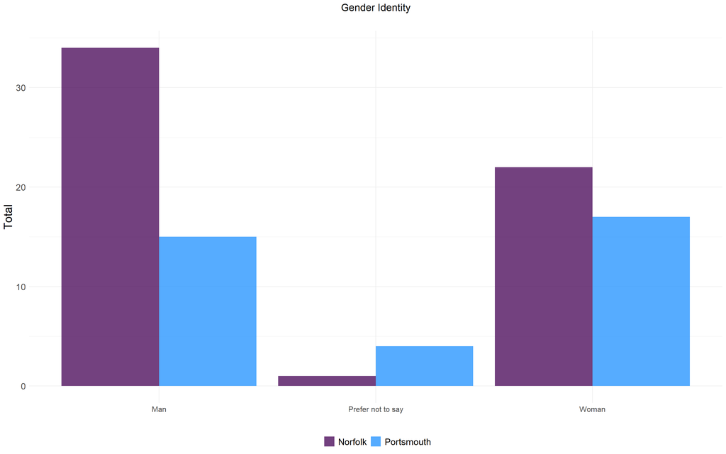

```r
recoded_data %>%
  group_by(City) %>%
  dplyr::select(Gender, City) %>%
  count(Gender) %>%
  ggplot() +
  geom_bar(aes(y = n, x = Gender, fill = City), stat = "identity", position = "dodge", alpha = 0.75) +
    scale_fill_manual(name = "",  values = c("#440154FF", "dodgerblue"), labels = c("Norfolk", "Portsmouth")) +
  labs(x = "", y = "Total", title =  "Gender Identity", subtitle = "") +
  theme_minimal() +
  theme(legend.position="bottom",
        plot.subtitle = element_text(hjust = 0.5),
        plot.title = element_text(hjust = 0.5, size = 16),
        axis.text.x = element_text(size = 12),
        text = element_text(size = 18))
```

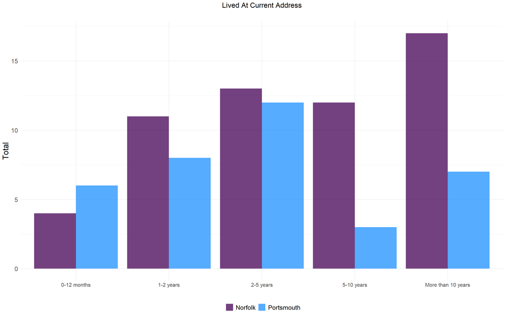

```r
recoded_data %>%
  group_by(City) %>%
  dplyr::select(Lived_At_Address, City) %>%
  count(Lived_At_Address) %>%
  ggplot() +
  geom_bar(aes(y = n, x = Lived_At_Address, fill = City), stat = "identity", position = "dodge", alpha = 0.75) +
    scale_fill_manual(name = "",  values = c("#440154FF", "dodgerblue"), labels = c("Norfolk", "Portsmouth")) +
  labs(x = "", y = "Total", title =  "Lived At Current Address", subtitle = "") +
  theme_minimal() +
  theme(legend.position="bottom",
        plot.subtitle = element_text(hjust = 0.5),
        plot.title = element_text(hjust = 0.5, size = 16),
        axis.text.x = element_text(size = 12),
        text = element_text(size = 18))
```

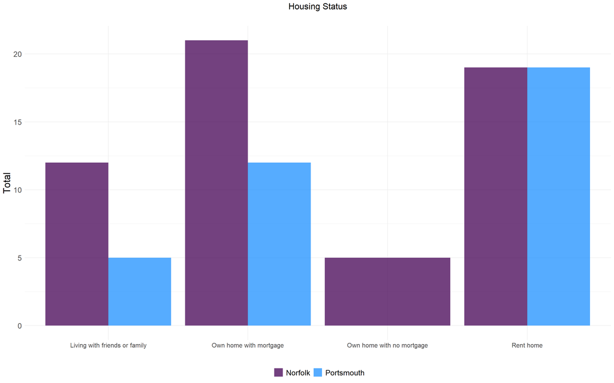

```r
recoded_data %>%
  group_by(City) %>%
  dplyr::select(Housing_Status, City) %>%
  count(Housing_Status) %>%
  ggplot() +
  geom_bar(aes(y = n, x = Housing_Status, fill = City), stat = "identity", position = "dodge", alpha = 0.75) +
    scale_fill_manual(name = "",  values = c("#440154FF", "dodgerblue"), labels = c("Norfolk", "Portsmouth")) +
  labs(x = "", y = "Total", title =  "Housing Status", subtitle = "") +
  theme_minimal() +
  theme(legend.position="bottom",
        plot.subtitle = element_text(hjust = 0.5),
        plot.title = element_text(hjust = 0.5, size = 16),
        axis.text.x = element_text(size = 12),
        text = element_text(size = 18))
```

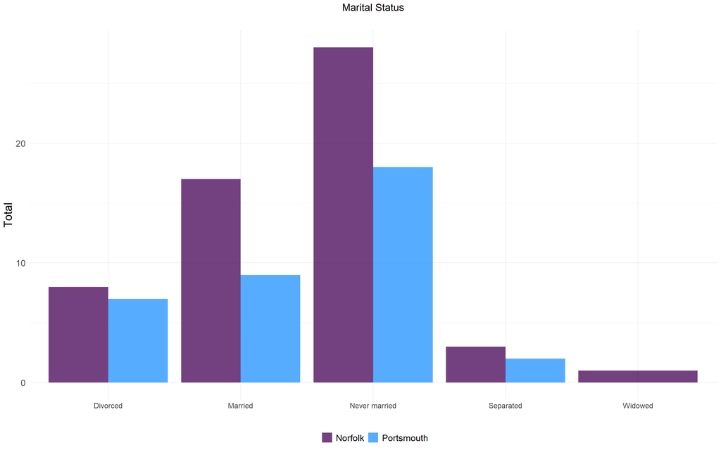

```r
recoded_data %>%
  group_by(City) %>%
  dplyr::select(Marital_Status, City) %>%
  count(Marital_Status) %>%
  ggplot() +
  geom_bar(aes(y = n, x = Marital_Status, fill = City), stat = "identity", position = "dodge", alpha = 0.75) +
    scale_fill_manual(name = "",  values = c("#440154FF", "dodgerblue"), labels = c("Norfolk", "Portsmouth")) +
  labs(x = "", y = "Total", title =  "Marital Status", subtitle = "") +
  theme_minimal() +
  theme(legend.position="bottom",
        plot.subtitle = element_text(hjust = 0.5),
        plot.title = element_text(hjust = 0.5, size = 16),
        axis.text.x = element_text(size = 12),
        text = element_text(size = 18))
```

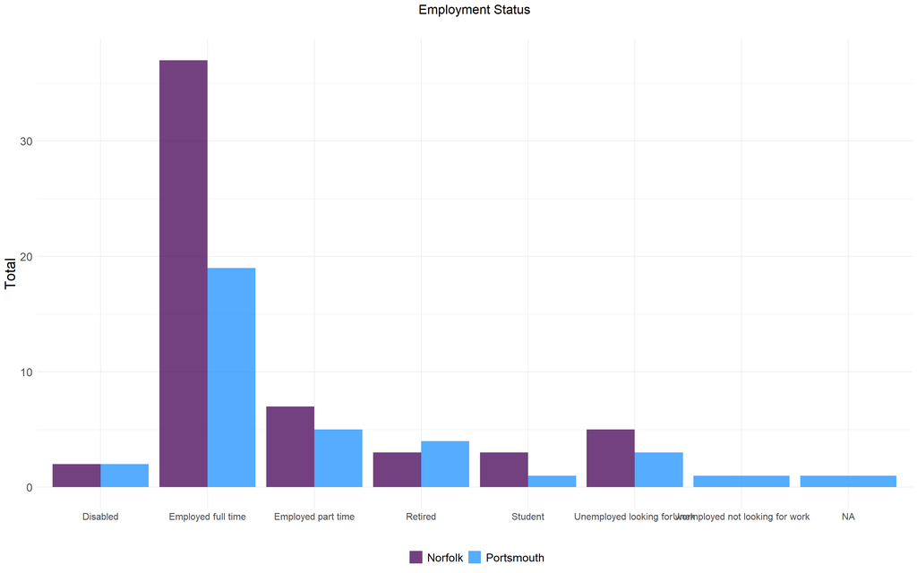

```r
recoded_data %>%
  group_by(City) %>%
  dplyr::select(Employ_Status, City) %>%
  count(Employ_Status) %>%
  ggplot() +
  geom_bar(aes(y = n, x = Employ_Status, fill = City), stat = "identity", position = "dodge", alpha = 0.75) +
    scale_fill_manual(name = "",  values = c("#440154FF", "dodgerblue"), labels = c("Norfolk", "Portsmouth")) +
  labs(x = "", y = "Total", title =  "Employment Status", subtitle = "") +
  theme_minimal() +
  theme(legend.position="bottom",
        plot.subtitle = element_text(hjust = 0.5),
        plot.title = element_text(hjust = 0.5, size = 16),
        axis.text.x = element_text(size = 12),
        text = element_text(size = 18))
```

```r
kbl(
recoded_data %>%
  group_by(City) %>%
  dplyr::select(BA_Plus_Educ, Employ_FT, Disability, City) %>%
  `colnames<-`(c("Bachelor's Degree or Higher", "Employed Full Time", "Has Health Condition or Disability", "City")) %>%
  rstatix::get_summary_stats(show = c("min", "max", "mean", "sd"))
) %>%
  kable_paper(bootstrap_options = "striped", full_width = F)
```

| City | variable | n | min | max | mean | sd |
| --- | --- | --- | --- | --- | --- | --- |
| Norfolk | Bachelor's Degree or Higher | 57 | 0 | 1 | 0.404 | 0.495 |
| Norfolk | Employed Full Time | 57 | 0 | 1 | 0.649 | 0.481 |
| Norfolk | Has Health Condition or Disability | 57 | 0 | 1 | 0.386 | 0.491 |
| Portsmouth | Bachelor's Degree or Higher | 36 | 0 | 1 | 0.139 | 0.351 |
| Portsmouth | Employed Full Time | 36 | 0 | 1 | 0.528 | 0.506 |
| Portsmouth | Has Health Condition or Disability | 36 | 0 | 1 | 0.500 | 0.507 |

```r
kruskal_test(data = recoded_data, formula = BA_Plus_Educ ~ City)
```

```
# A tibble: 1 × 6
  .y.              n statistic    df       p method
* <chr>        <int>     <dbl> <int>   <dbl> <chr>
1 BA_Plus_Educ    93      7.26     1 0.00704 Kruskal-Wallis
```

```r
kruskal_test(data = recoded_data, formula = Employ_FT ~ City)
```

```
# A tibble: 1 × 6
  .y.           n statistic    df     p method
* <chr>     <int>     <dbl> <int> <dbl> <chr>
1 Employ_FT    93      1.34     1 0.247 Kruskal-Wallis
```

```r
kruskal_test(data = recoded_data, formula = Disability ~ City)
```

```
# A tibble: 1 × 6
  .y.            n statistic    df     p method
* <chr>      <int>     <dbl> <int> <dbl> <chr>
1 Disability    93      1.16     1 0.282 Kruskal-Wallis
```

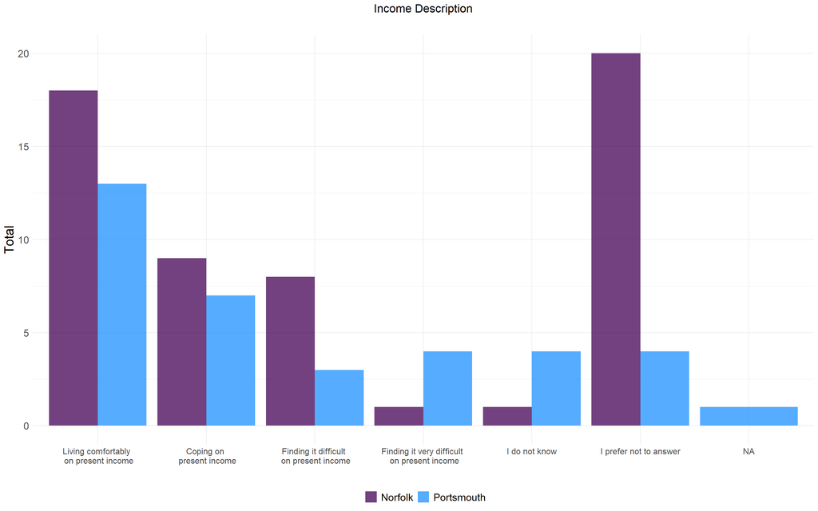

```r
recoded_data %>%
  group_by(City) %>%
  dplyr::select(Income_Desc, City) %>%
  count(Income_Desc) %>%
  ggplot() +
  geom_bar(aes(y = n, x = Income_Desc, fill = City), stat = "identity", position = "dodge", alpha = 0.75) +
    scale_fill_manual(name = "",  values = c("#440154FF", "dodgerblue"), labels = c("Norfolk", "Portsmouth")) +
  labs(x = "", y = "Total", title =  "Income Description", subtitle = "") +
  scale_x_discrete(labels=c('Living comfortably \n on present income', 'Coping on \n present income',
                            'Finding it difficult \n on present income', 'Finding it very difficult \n on present income',
                            'I do not know', 'I prefer not to answer')) +
  theme_minimal() +
  theme(legend.position="bottom",
        plot.subtitle = element_text(hjust = 0.5),
        plot.title = element_text(hjust = 0.5, size = 16),
        axis.text.x = element_text(size = 12),
        text = element_text(size = 18))
```

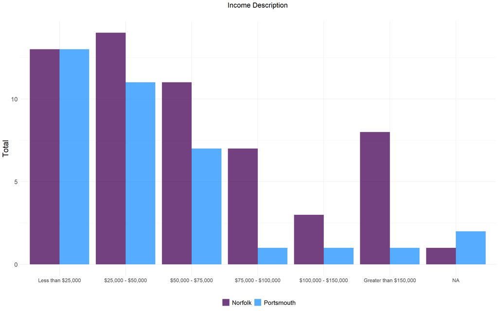

```r
recoded_data %>%
  group_by(City) %>%
  dplyr::select(Income_Range, City, Income_Range_Levels) %>%
  count(Income_Range, Income_Range_Levels) %>%
  ggplot() +
  geom_bar(aes(y = n, x = Income_Range_Levels, fill = City), stat = "identity", position = "dodge", alpha = 0.75) +
    scale_fill_manual(name = "",  values = c("#440154FF", "dodgerblue"), labels = c("Norfolk", "Portsmouth")) +
  labs(x = "", y = "Total", title =  "Income Description", subtitle = "") +
  theme_minimal() +
  theme(legend.position="bottom",
        plot.subtitle = element_text(hjust = 0.5),
        plot.title = element_text(hjust = 0.5, size = 16),
        axis.text.x = element_text(size = 12),
        text = element_text(size = 18))
```

```r
kbl(
recoded_data %>%
  group_by(City) %>%
  dplyr::select(Num_Children, Dependents, Married, City) %>%
  `colnames<-`(c("Number of Children", "Number of Dependents", "Married", "City")) %>%
  rstatix::get_summary_stats(show = c("min", "max", "mean", "sd"))
) %>%
  kable_paper(bootstrap_options = "striped", full_width = F)
```

| City | variable | n | min | max | mean | sd |
| --- | --- | --- | --- | --- | --- | --- |
| Norfolk | Number of Children | 57 | 0 | 4 | 0.596 | 0.942 |
| Norfolk | Number of Dependents | 55 | 0 | 4 | 0.582 | 1.049 |
| Norfolk | Married | 57 | 0 | 1 | 0.298 | 0.462 |
| Portsmouth | Number of Children | 35 | 0 | 4 | 0.429 | 0.948 |
| Portsmouth | Number of Dependents | 35 | 0 | 6 | 0.857 | 1.309 |
| Portsmouth | Married | 36 | 0 | 1 | 0.250 | 0.439 |

```r
kruskal_test(data = recoded_data, formula = Num_Children ~ City)
```

```
# A tibble: 1 × 6
  .y.              n statistic    df     p method
* <chr>        <int>     <dbl> <int> <dbl> <chr>
1 Num_Children    93      1.62     1 0.203 Kruskal-Wallis
```

```r
kruskal_test(data = recoded_data, formula = Dependents ~ City)
```

```
# A tibble: 1 × 6
  .y.            n statistic    df     p method
* <chr>      <int>     <dbl> <int> <dbl> <chr>
1 Dependents    93      1.64     1   0.2 Kruskal-Wallis
```

```r
kruskal_test(data = recoded_data, formula = Married ~ City)
```

```
# A tibble: 1 × 6
  .y.         n statistic    df     p method
* <chr>   <int>     <dbl> <int> <dbl> <chr>
1 Married    93     0.252     1 0.615 Kruskal-Wallis
```

```r
kbl(
recoded_data %>%
  group_by(City) %>%
  dplyr::select(Has_Car, Has_Garden, Has_Dog, City) %>%
  `colnames<-`(c("Access To Car", "Access To Garden", "Has A Dog", "City")) %>%
  rstatix::get_summary_stats(show = c("min", "max", "mean", "sd"))
) %>%
  kable_paper(bootstrap_options = "striped", full_width = F)
```

| City | variable | n | min | max | mean | sd |
| --- | --- | --- | --- | --- | --- | --- |
| Norfolk | Access To Car | 57 | 0 | 1 | 0.895 | 0.310 |
| Norfolk | Access To Garden | 57 | 0 | 1 | 0.544 | 0.503 |
| Norfolk | Has A Dog | 57 | 0 | 1 | 0.333 | 0.476 |
| Portsmouth | Access To Car | 36 | 0 | 1 | 0.833 | 0.378 |
| Portsmouth | Access To Garden | 36 | 0 | 1 | 0.306 | 0.467 |
| Portsmouth | Has A Dog | 36 | 0 | 1 | 0.389 | 0.494 |

```r
kruskal_test(data = recoded_data, formula = Has_Car ~ City)
```

```
# A tibble: 1 × 6
  .y.         n statistic    df     p method
* <chr>   <int>     <dbl> <int> <dbl> <chr>
1 Has_Car    93     0.732     1 0.392 Kruskal-Wallis
```

```r
kruskal_test(data = recoded_data, formula = Has_Garden ~ City)
```

```
# A tibble: 1 × 6
  .y.            n statistic    df      p method
* <chr>      <int>     <dbl> <int>  <dbl> <chr>
1 Has_Garden    93      5.01     1 0.0253 Kruskal-Wallis
```

```r
kruskal_test(data = recoded_data, formula = Has_Dog ~ City)
```

```
# A tibble: 1 × 6
  .y.         n statistic    df     p method
* <chr>   <int>     <dbl> <int> <dbl> <chr>
1 Has_Dog    93     0.294     1 0.587 Kruskal-Wallis
```

In terms of age distribution, there were far more respondents from Portsmouth in the 60+ years category than from Norfolk—the two distributions are otherwise similar. There appears to have been more parity in gender identity for Portsmouth respondents.

The responses to the *How long have you lived in your current home?* question skew towards longer-term residents in Norfolk. The majority of respondents (41%) are renters while in Norfolk that number is 33% and in Portsmouth 53% are renters.

Marital status is similarly distributed between Norfolk and Portsmouth respondents, but far more Portsmouth respondents have other dependents (i.e., not children) living in the household.

Educational attainment (i.e., respondents with a Bachelor’s degree or higher) is higher in Norfolk and this difference is statistically significant (kw = 7.26, p = 0.007). Reported incomes were higher in Norfolk while more Portsmouth respondents indicated they were *“Finding it very difficult on present income”*.

There is a statistically significant difference in access to a garden with this being more likely among Norfolk respondents (kw = 5.01, p = 0.025).

Note the higher percentage of respondents with a health condition or disability in Portsmouth.

What did respondents report when asked *How far away from your home is [the park] by walking?*

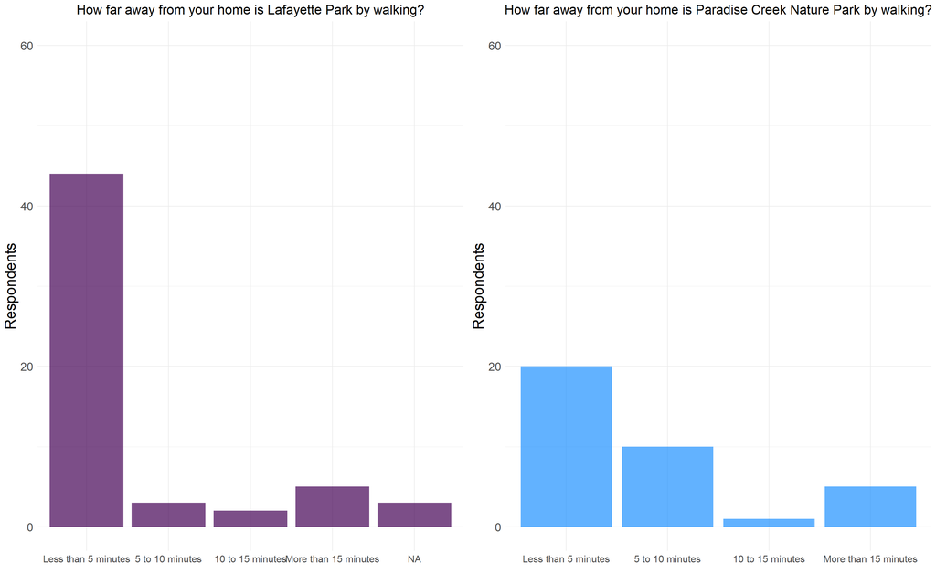

```r
portsmouth_distance <- data_1 %>% dplyr::filter(Q02 == "Portsmouth") %>%
  count(Q50_fact) %>%
  ggplot() +
  geom_bar(aes(x = Q50_fact, y = n), stat = "identity", fill = "dodgerblue", alpha = 0.7) +
  labs(x = " ", y = "Respondents", title = "How far away from your home is Paradise Creek Nature Park by walking?") +
  ylim(c(0, 60)) +
  theme_minimal() +
  theme(plot.title = element_text(hjust = 0.5, size = 16),
        axis.text.x = element_text(size = 12),
        text = element_text(size = 18))

# ggsave("Paradise Creek Distance By Walking.png", units = "in",
#        width = 16, height = 8, bg = "white")




norfolk_distance <- data_1 %>% dplyr::filter(Q02 == "Norfolk") %>%
  count(Q30_fact) %>%
  ggplot() +
  geom_bar(aes(x = Q30_fact, y = n), stat = "identity", fill = "#440154FF", alpha = 0.7) +
  labs(x = " ", y = "Respondents", title = "How far away from your home is Lafayette Park by walking?") +
  ylim(c(0, 60)) +
  theme_minimal() +
  theme(plot.title = element_text(hjust = 0.5, size = 16),
        axis.text.x = element_text(size = 12),
        text = element_text(size = 18))

# ggsave("Lafayette Distance By Walking.png", units = "in",
#        width = 16, height = 8, bg = "white")



ggarrange(norfolk_distance, portsmouth_distance, ncol = 2, nrow = 1)
```

```r
ggsave("Distance By Walking Both Parks.png", units = "in",
       width = 16, height = 8, bg = "white")
```

We see that a greater percentage of respondents living near Paradise Creek Nature Park reported that it would take *5 to 10 minutes* to walk there from their home.

## Recode Data from Qualtrics Format

There are several sets of questions designed to capture dimensions of mental and physical well-being as well as social cohesion and neighborhood perceptions. The section below outlines how these question responses were coded to support analysis.

#### Relationships with Others

These responses comprise the UCLA-3 loneliness scale[^1] where a lower number represents **less** loneliness and are coded **1 = Hardly Ever, 2 = Some of the Time, 3 = Often**:

- How often do you feel that you lack companionship? → Q61_1
- How often do you feel left out? → Q61_2
- How often do you feel isolated from others? → Q61_3

#### Social Cohesion and Belonging

For the question below, a higher number represents greater belonging[^2] and are coded **1 = Not at all strongly, 2 = Not very strongly, 3 = Don’t know (neutral), 4 = Fairly strongly, 5 = Very strongly**:

- How strongly do you feel you belong to your neighborhood or local area? → Q62

#### Subjective Mental Wellbeing

For this measure[^3], a higher number represents higher mental well-being. These responses are coded **1 = None of the time, 2 = Rarely, 3 = Some of the time, 4 = Often, 5 = All of the time**:

- I’ve been feeling optimistic about the future (over the past two weeks). → Q63_1
- I’ve been feeling useful (over the past two weeks). → Q63_2
- I’ve been feeling relaxed (over the past two weeks). → Q63_3
- I’ve been dealing with problems (over the past two weeks). → Q63_4
- I’ve been thinking clearly (over the past two weeks). → Q63_5
- I’ve been feeling close to other people (over the past two weeks). → Q63_6
- I’ve been able to make up my own mind about things (over the past two weeks). → Q63_7

#### Perceived Stress

For this measure[^4] a lower number represents lower stress. These responses are coded **1 = Never, 2 = Almost never, 3 = Sometimes, 4 = Fairly often, 5 = Very often**:

- Felt that you were unable to control the important things in life? (in the last month). → Q64_1
- Doubted your ability to handle your personal problems? (in the last month). → Q64_2
- Felt that things were just not going your way? (in the last month). → Q64_3
- Felt difficulties were piling up so high that you could not overcome them? (in the last month). → Q64_4

#### General Health

In general would you say that, for a person of your age,your health is… **1 = Very poor, 2 = Poor, 3 = Neither poor nor good, 4 = Good, 5 = Very good**. → Q65

#### Physical Activity

Brisk physical activity (moderate to intense levels of activity), means it leaves you slightly out of breath and raises your heart rate slightly. Types of brisk physical activity can include walking, cycling, climbing stairs,gardening, energetic housework, etc.

- How much moderate to intense (or brisk) physical activity do you do on average per week? **1 = None, 2 = Less than 30 minutes, 3 = 30 mins to 1 hour, 4 = 1 hour to 1 ½ hour, 5 = More than 1 ½ hours**. → Q66
- During the last 7 days, on how many days did you walk for at least 10 minutes at a time? → Q67
- How much time (in minutes) did you usually spend walking on one of those days?? → Q68

#### Perception of Local Neighborhood

These questions capture a respondent’s perceptions of and satisfaction with the neighborhood. A higher value represents higher satisfaction with the local neighborhood.

- Would you advise a friend or relative to live in this neighborhood? **1 = Definitely not, 2 = Probably not, 3 = Might or might not, 4 = Probably yes, 5 = Definitely yes**. → Q69
- How satisfied are you with the quality of the physical environment in your local neighborhood? **1 = Extremely dissatisfied, 2 = Somewhat dissatisfied, 3 = Neither satisfied nor dissatisfied, 4 = Somewhat satisfied, 5 = Extremely satisfied**. → Q70
- Would you say most people in your neighborhood can be trusted? **1 = Definitely not, 2 = Probably not, 3 = Don’t know (neutral), 4 = Probably yes, 5 = Definitely yes**. → Q71

## Survey Findings

In addition to selected descriptive statistics, we used non-parametric [Kruskal-Wallis tests](https://en.wikipedia.org/wiki/Kruskal%E2%80%93Wallis_one-way_analysis_of_variance) to explore potential differences in outcomes of interest. Note that the **null hypothesis for the Kruskal-Wallis test** is that the median values of the variable of interest are the same across the groups being compared—this test is useful when the data are not normally distributed or when they are ordinal (e.g., Likert scales).

### Relationships with Others

```r
kbl(
recoded_data %>%
  group_by(City) %>%
  dplyr::select(Lack_Compan, Left_Out, Isolat_Others, City) %>%
  `colnames<-`(c("Lack Companionship", "Feel Left Out", "Feel Isolated", "City")) %>%
  rstatix::get_summary_stats(show = c("min", "max", "mean", "sd"))
) %>%
  kable_paper(bootstrap_options = "striped", full_width = F)
```

| City | variable | n | min | max | mean | sd |
| --- | --- | --- | --- | --- | --- | --- |
| Norfolk | Lack Companionship | 57 | 1 | 3 | 1.579 | 0.565 |
| Norfolk | Feel Left Out | 57 | 1 | 3 | 1.509 | 0.630 |
| Norfolk | Feel Isolated | 57 | 1 | 3 | 1.579 | 0.565 |
| Portsmouth | Lack Companionship | 35 | 1 | 3 | 1.657 | 0.725 |
| Portsmouth | Feel Left Out | 35 | 1 | 3 | 1.457 | 0.611 |
| Portsmouth | Feel Isolated | 35 | 1 | 3 | 1.514 | 0.562 |

```r
kruskal_test(data = recoded_data, formula = Lack_Compan ~ City)
```

```
# A tibble: 1 × 6
  .y.             n statistic    df     p method
* <chr>       <int>     <dbl> <int> <dbl> <chr>
1 Lack_Compan    93    0.0725     1 0.788 Kruskal-Wallis
```

```r
wilcox_test(formula = Lack_Compan ~ City, data = recoded_data)
```

```
# A tibble: 1 × 7
  .y.         group1  group2        n1    n2 statistic     p
* <chr>       <chr>   <chr>      <int> <int>     <dbl> <dbl>
1 Lack_Compan Norfolk Portsmouth    57    35      968. 0.791
```

```r
kruskal_test(data = recoded_data, formula = Left_Out ~ City)
```

```
# A tibble: 1 × 6
  .y.          n statistic    df     p method
* <chr>    <int>     <dbl> <int> <dbl> <chr>
1 Left_Out    93     0.146     1 0.702 Kruskal-Wallis
```

```r
wilcox_test(formula = Left_Out ~ City, data = recoded_data)
```

```
# A tibble: 1 × 7
  .y.      group1  group2        n1    n2 statistic     p
* <chr>    <chr>   <chr>      <int> <int>     <dbl> <dbl>
1 Left_Out Norfolk Portsmouth    57    35      1039 0.706
```

```r
kruskal_test(data = recoded_data, formula = Isolat_Others ~ City)
```

```
# A tibble: 1 × 6
  .y.               n statistic    df     p method
* <chr>         <int>     <dbl> <int> <dbl> <chr>
1 Isolat_Others    93     0.296     1 0.586 Kruskal-Wallis
```

```r
wilcox_test(formula = Isolat_Others ~ City, data = recoded_data)
```

```
# A tibble: 1 × 7
  .y.           group1  group2        n1    n2 statistic     p
* <chr>         <chr>   <chr>      <int> <int>     <dbl> <dbl>
1 Isolat_Others Norfolk Portsmouth    57    35      1057  0.59
```

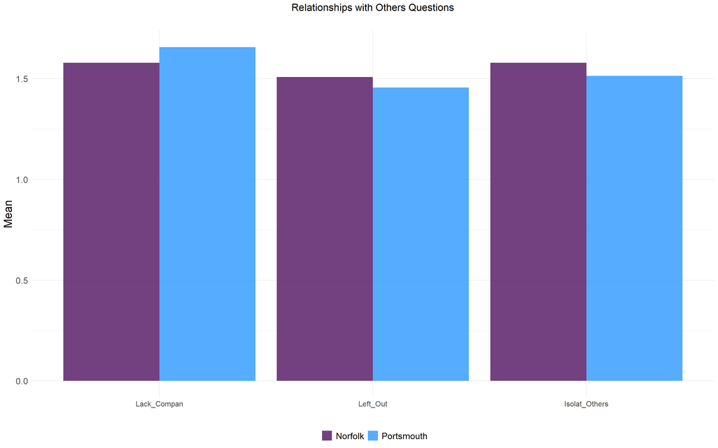

```r
recoded_data %>%
  group_by(City) %>%
  dplyr::select(Lack_Compan, Left_Out, Isolat_Others, City) %>%
  rstatix::get_summary_stats(type = "common") %>%
  ggplot() +
  geom_bar(aes(y = mean, x = variable, fill = City), stat = "identity", position = "dodge", alpha = 0.75) +
    scale_fill_manual(name = "",  values = c("#440154FF", "dodgerblue"), labels = c("Norfolk", "Portsmouth")) +
  labs(x = "", y = "Mean", title =  "Relationships with Others Questions", subtitle = "") +
  theme_minimal() +
  theme(legend.position="bottom",
        plot.subtitle = element_text(hjust = 0.5),
        plot.title = element_text(hjust = 0.5, size = 16),
        axis.text.x = element_text(size = 12),
        text = element_text(size = 18))
```

There are no statistically significant differences in any of the *Relationships with Others* questions among the Norfolk and Portsmouth respondents.

### Social Cohesion and Belonging

```r
kruskal_test(data = recoded_data, formula = Belong_Neighborhood ~ City)
```

```
# A tibble: 1 × 6
  .y.                     n statistic    df     p method
* <chr>               <int>     <dbl> <int> <dbl> <chr>
1 Belong_Neighborhood    93     0.111     1 0.739 Kruskal-Wallis
```

```r
wilcox_test(data = recoded_data, formula = Belong_Neighborhood ~ City)
```

```
# A tibble: 1 × 7
  .y.                 group1  group2        n1    n2 statistic     p
* <chr>               <chr>   <chr>      <int> <int>     <dbl> <dbl>
1 Belong_Neighborhood Norfolk Portsmouth    57    35      958. 0.742
```

There is no statistically significant difference in how respondents in Norfolk and Portsmouth answered the *How strongly do you feel you belong to your neighborhood or local area?* question.

### Subjective Mental Wellbeing

```r
kbl(
recoded_data %>%
  group_by(City) %>%
  dplyr::select(Subj_Mental_1, Subj_Mental_2, Subj_Mental_3, Subj_Mental_4, Subj_Mental_5, Subj_Mental_6, Subj_Mental_7, City) %>%
  `colnames<-`(c("Optimistic About Future", "Feeling Useful", "Feeling Relaxed",
                 "Dealing With Problems", "Thinking Clearly", "Feeling Close to Others", "Make Up Own Mind",  "City")) %>%
  rstatix::get_summary_stats(show = c("min", "max", "mean", "sd"))
) %>%
  kable_paper(bootstrap_options = "striped", full_width = F)
```

| City | variable | n | min | max | mean | sd |
| --- | --- | --- | --- | --- | --- | --- |
| Norfolk | Optimistic About Future | 57 | 1 | 5 | 3.456 | 1.036 |
| Norfolk | Feeling Useful | 57 | 2 | 5 | 3.895 | 0.748 |
| Norfolk | Feeling Relaxed | 56 | 1 | 5 | 3.339 | 0.978 |
| Norfolk | Dealing With Problems | 57 | 1 | 5 | 3.439 | 0.887 |
| Norfolk | Thinking Clearly | 57 | 3 | 5 | 4.053 | 0.742 |
| Norfolk | Feeling Close to Others | 57 | 1 | 5 | 3.526 | 0.984 |
| Norfolk | Make Up Own Mind | 56 | 2 | 5 | 4.143 | 0.841 |
| Portsmouth | Optimistic About Future | 35 | 1 | 5 | 3.543 | 1.120 |
| Portsmouth | Feeling Useful | 35 | 1 | 5 | 3.857 | 1.192 |
| Portsmouth | Feeling Relaxed | 35 | 1 | 5 | 3.400 | 1.006 |
| Portsmouth | Dealing With Problems | 35 | 1 | 5 | 3.257 | 1.120 |
| Portsmouth | Thinking Clearly | 35 | 2 | 5 | 4.000 | 0.804 |
| Portsmouth | Feeling Close to Others | 35 | 1 | 5 | 3.600 | 1.063 |
| Portsmouth | Make Up Own Mind | 35 | 3 | 5 | 4.314 | 0.832 |

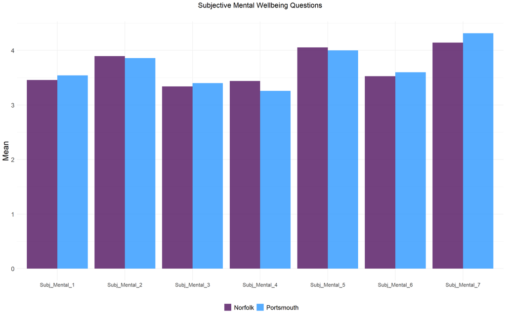

```r
# kruskal_test(data = recoded_data, formula = Subj_Mental_1 ~ City)
# wilcox_test(data = recoded_data, formula = Subj_Mental_1 ~ City)


recoded_data %>%
  group_by(City) %>%
  dplyr::select(Subj_Mental_1, Subj_Mental_2, Subj_Mental_3, Subj_Mental_4, Subj_Mental_5, Subj_Mental_6, Subj_Mental_7, City) %>%
  rstatix::get_summary_stats(type = "common") %>%
  ggplot() +
  geom_bar(aes(y = mean, x = variable, fill = City), stat = "identity", position = "dodge", alpha = 0.75) +
    scale_fill_manual(name = "",  values = c("#440154FF", "dodgerblue"), labels = c("Norfolk", "Portsmouth")) +
  labs(x = "", y = "Mean", title =  "Subjective Mental Wellbeing Questions", subtitle = "") +
  theme_minimal() +
  theme(legend.position="bottom",
        plot.subtitle = element_text(hjust = 0.5),
        plot.title = element_text(hjust = 0.5, size = 16),
        axis.text.x = element_text(size = 12),
        text = element_text(size = 18))
```

There were no statistically significant differences between Norfolk and Portsmouth respondents for any of the *Subjective Mental Wellbeing* questions.

### Perceived Stress

```r
kbl(
recoded_data %>%
  group_by(City) %>%
  dplyr::select(Perceive_Stress_1, Perceive_Stress_2, Perceive_Stress_3, Perceive_Stress_4, City) %>%
  `colnames<-`(c("Unable To Control Important Things", "Doubted Ability Handle Problems",
                 "Things Not Going My Way", "Cannot Overcome Difficulties", "City")) %>%
  rstatix::get_summary_stats(show = c("min", "max", "mean", "sd"))
) %>%
  kable_paper(bootstrap_options = "striped", full_width = F)
```

| City | variable | n | min | max | mean | sd |
| --- | --- | --- | --- | --- | --- | --- |
| Norfolk | Unable To Control Important Things | 57 | 1 | 5 | 2.982 | 1.026 |
| Norfolk | Doubted Ability Handle Problems | 57 | 1 | 5 | 2.491 | 0.928 |
| Norfolk | Things Not Going My Way | 57 | 1 | 5 | 2.947 | 1.007 |
| Norfolk | Cannot Overcome Difficulties | 57 | 1 | 5 | 2.754 | 1.138 |
| Portsmouth | Unable To Control Important Things | 35 | 1 | 4 | 2.343 | 0.938 |
| Portsmouth | Doubted Ability Handle Problems | 35 | 1 | 4 | 2.171 | 1.043 |
| Portsmouth | Things Not Going My Way | 35 | 1 | 5 | 2.800 | 1.106 |
| Portsmouth | Cannot Overcome Difficulties | 35 | 1 | 5 | 2.400 | 1.143 |

```r
kruskal_test(data = recoded_data, formula = Perceive_Stress_1 ~ City)
```

```
# A tibble: 1 × 6
  .y.                   n statistic    df       p method
* <chr>             <int>     <dbl> <int>   <dbl> <chr>
1 Perceive_Stress_1    93      7.02     1 0.00808 Kruskal-Wallis
```

### Physical Activity

```r
kbl(
recoded_data %>%
  group_by(City) %>%
  dplyr::select(Physical_Activity, Walking_Days, Walking_Minutes, City) %>%
  `colnames<-`(c("Brisk Physical Activity", "Days Walked 10+ Mins", "Minutes Walking", "City")) %>%
  rstatix::get_summary_stats(show = c("min", "max", "mean", "sd"))
) %>%
  kable_paper(bootstrap_options = "striped", full_width = F)
```

| City | variable | n | min | max | mean | sd |
| --- | --- | --- | --- | --- | --- | --- |
| Norfolk | Brisk Physical Activity | 57 | 1 | 5 | 3.930 | 1.237 |
| Norfolk | Days Walked 10+ Mins | 57 | 1 | 7 | 5.053 | 1.995 |
| Norfolk | Minutes Walking | 56 | 5 | 480 | 44.982 | 69.174 |
| Portsmouth | Brisk Physical Activity | 35 | 1 | 5 | 3.200 | 1.530 |
| Portsmouth | Days Walked 10+ Mins | 36 | 0 | 7 | 4.833 | 1.920 |
| Portsmouth | Minutes Walking | 35 | 8 | 450 | 70.314 | 102.277 |

```r
kruskal_test(data = recoded_data, formula = Physical_Activity ~ City)
```

```
# A tibble: 1 × 6
  .y.                   n statistic    df      p method
* <chr>             <int>     <dbl> <int>  <dbl> <chr>
1 Physical_Activity    93      5.19     1 0.0227 Kruskal-Wallis
```

```r
kruskal_test(data = recoded_data, formula = Walking_Days ~ City)
```

```
# A tibble: 1 × 6
  .y.              n statistic    df     p method
* <chr>        <int>     <dbl> <int> <dbl> <chr>
1 Walking_Days    93     0.319     1 0.572 Kruskal-Wallis
```

```r
kruskal_test(data = recoded_data, formula = Walking_Minutes ~ City)
```

```
# A tibble: 1 × 6
  .y.                 n statistic    df     p method
* <chr>           <int>     <dbl> <int> <dbl> <chr>
1 Walking_Minutes    93      1.59     1 0.207 Kruskal-Wallis
```

```r
kruskal_test(data = recoded_data, formula = General_Health ~ City)
```

```
# A tibble: 1 × 6
  .y.                n statistic    df     p method
* <chr>          <int>     <dbl> <int> <dbl> <chr>
1 General_Health    93      1.01     1 0.315 Kruskal-Wallis
```

Respondents from Norfolk (mean = 3.93, sd = 1.24) reported getting more brisk physical activity than their counterparts in Portsmouth (mean = 3.20, sd = 1.53) and these differences are significant at the 0.05 alpha level (kw = 5.19, p = 0.023) based on a Kruskal-Wallis test.

There was not a statistically significant difference between Norfolk and Portsmouth respondents in the self-reported health assessment question (i.e., *In general would you say that, for a person of your age,your health is…*).

### Perception of Local Neighborhood

```r
kbl(
recoded_data %>%
  group_by(City) %>%
  dplyr::select(Belong_Neighborhood, Advise_Friend, Phys_Quality_Nhood, Trust_Neighbors, City) %>%
  `colnames<-`(c("I Belong This Neighborhood", "Would Advise Friend Live Here", "Satis Phys Quality Neighborhood", "Neighbors Can Be Trusted", "City")) %>%
  rstatix::get_summary_stats(show = c("min", "max", "mean", "sd"))
) %>%
  kable_paper(bootstrap_options = "striped", full_width = F)
```

| City | variable | n | min | max | mean | sd |
| --- | --- | --- | --- | --- | --- | --- |
| Norfolk | I Belong This Neighborhood | 57 | 1 | 5 | 3.351 | 1.203 |
| Norfolk | Would Advise Friend Live Here | 56 | 1 | 5 | 3.929 | 0.871 |
| Norfolk | Satis Phys Quality Neighborhood | 56 | 2 | 5 | 3.518 | 1.027 |
| Norfolk | Neighbors Can Be Trusted | 56 | 1 | 5 | 3.214 | 0.909 |
| Portsmouth | I Belong This Neighborhood | 35 | 1 | 5 | 3.457 | 1.172 |
| Portsmouth | Would Advise Friend Live Here | 35 | 1 | 5 | 3.400 | 1.090 |
| Portsmouth | Satis Phys Quality Neighborhood | 35 | 1 | 5 | 3.286 | 1.178 |
| Portsmouth | Neighbors Can Be Trusted | 35 | 1 | 5 | 2.657 | 0.938 |

```r
kruskal_test(data = recoded_data, formula = Trust_Neighbors ~ City)
```

```
# A tibble: 1 × 6
  .y.                 n statistic    df       p method
* <chr>           <int>     <dbl> <int>   <dbl> <chr>
1 Trust_Neighbors    93      7.09     1 0.00776 Kruskal-Wallis
```

## Footnotes

[^1]: Russell, D. W. (1996). UCLA Loneliness Scale (Version 3): Reliability, validity, and factor structure. Journal of personality assessment, 66(1), 20-40.
[^2]: Malone, G. P., Pillow, D. R., & Osman, A. (2012). The general belongingness scale (GBS): Assessing achieved belongingness. Personality and individual differences, 52(3), 311-316.
[^3]: Smith, O. R., Alves, D. E., Knapstad, M., Haug, E., & Aarø, L. E. (2017). Measuring mental well-being in Norway: validation of the Warwick-Edinburgh Mental Well-being Scale (WEMWBS). Bmc Psychiatry, 17, 1-9.
[^4]: Perceived Stress Scale, PSS-4, (Wartig et al, 2013) adapted from Cohen, S., Kamarck, T., & Mermelstein, R. (1983). A global measure of perceived stress. Journal of Health and Social Behavior, 24, 385-396.